# Voti Verifica

8 marzo 2025

## Compiti per Casa

## Consegna compiti per casa

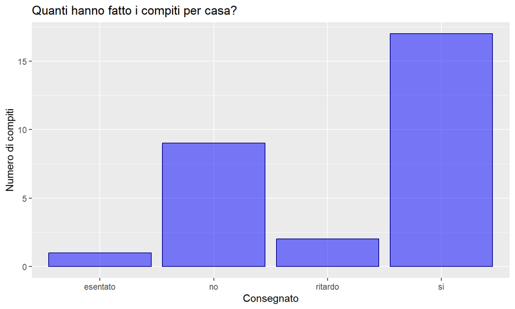

## Consegna compiti per casa

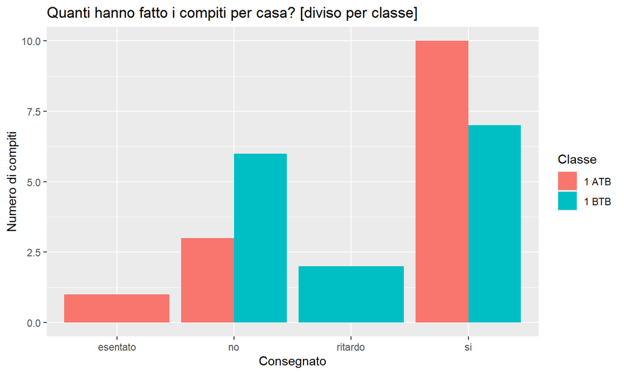

## Voti Verifica

## Distribuzione Voti della Verifica

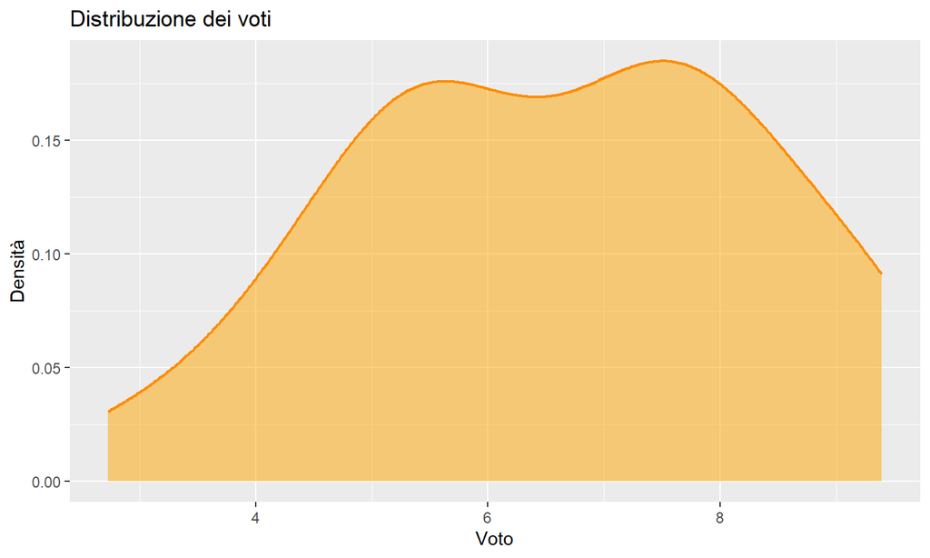

## Dati interessanti

- La **media** è **6.59**
- La **mediana** è **6.97**
- Il **voto massimo** è **9.39**
- Il **voto minimo** è **2.73**

## Dati interessanti per Classe

- La **media** della 1 ATB è **6.68**
- La **mediana** della 1 ATB è **6.97**
- La **media** della 1 BTB è **6.50**
- La **mediana** della 1 BTB è **6.06**

## Distribuzione Voti della Verifica per Classe

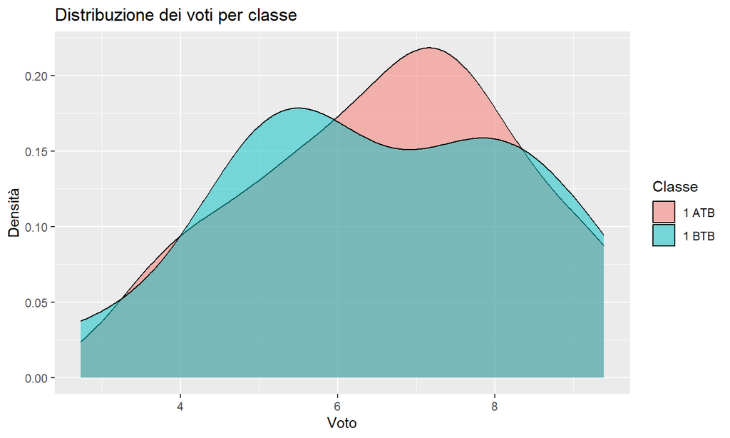

## Distribuzione Voti se si consegnano i Compiti

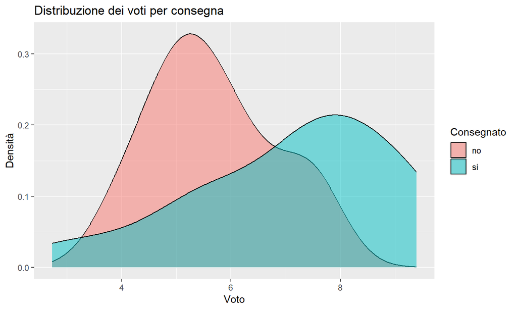

## Andamento esercizi

## Com’è andato il primo esercizio?

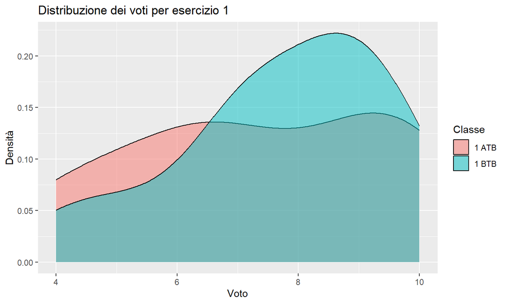

## Com’è andato il secondo esercizio?

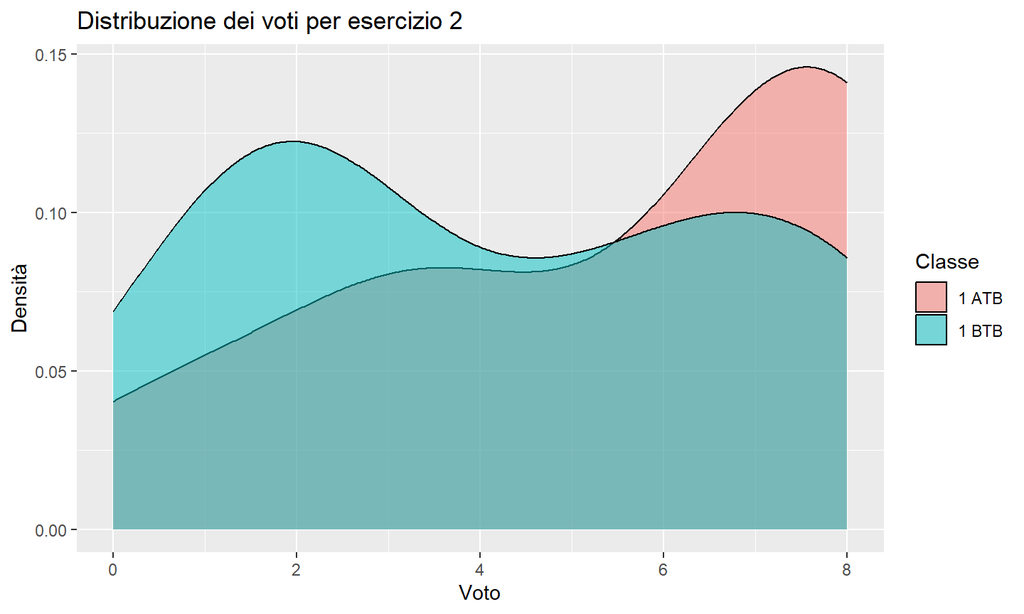

## Com’è andato il terzo esercizio?

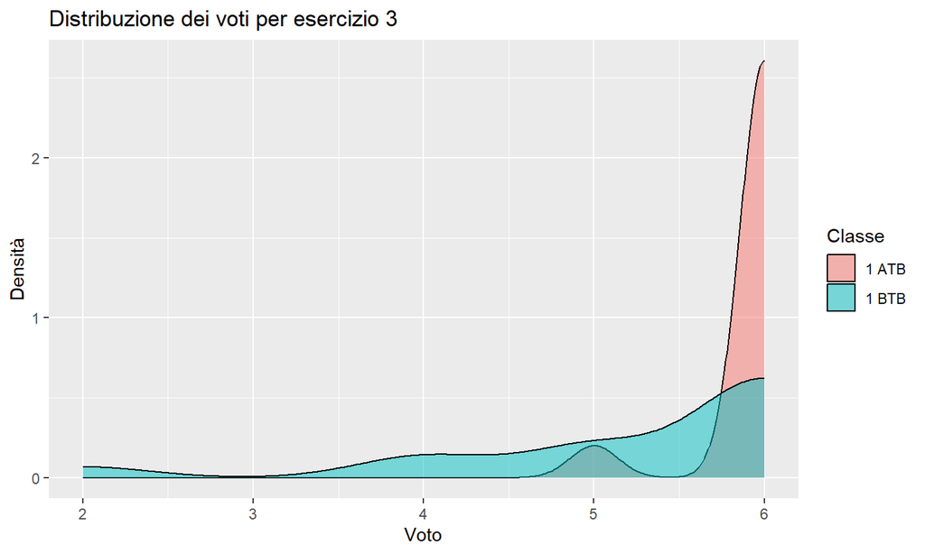

## Com’è andato il quarto esercizio?

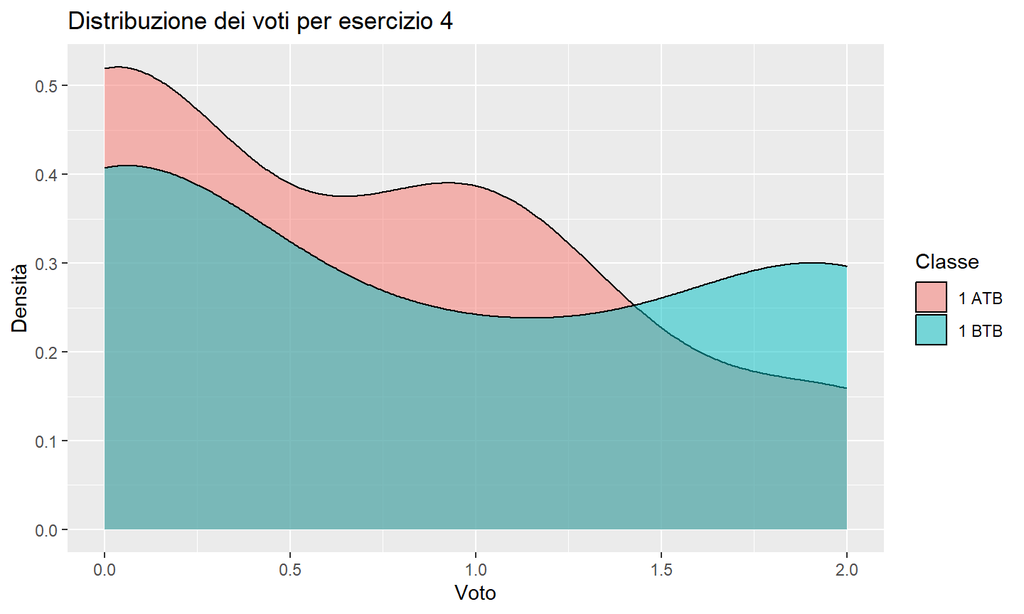

## Com’è andato il quinto esercizio?

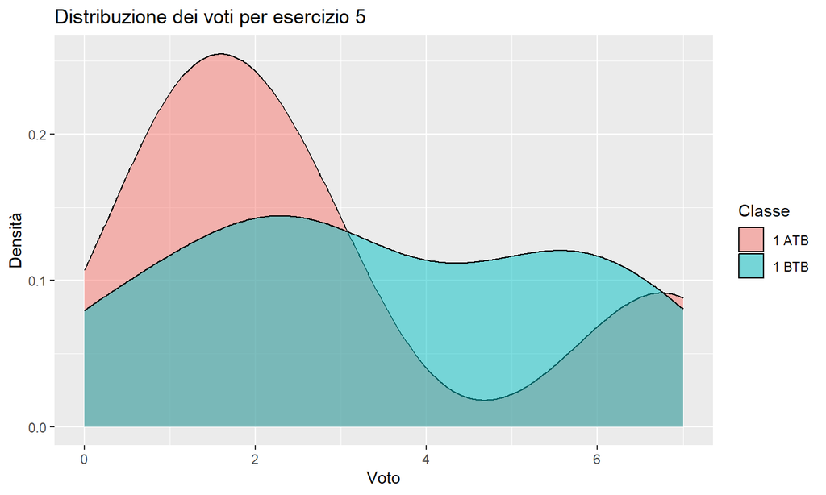

## Conclusioni

## Sono stato cattivo?

La differenza tra i voti **che ho messo**, arrotondando, e i risultati veri è di **0.3** punti.

- Cosa avete trovato difficile?
- Avete fatto gli esercizi per casa?
- Siete stati sorpresi dagli esercizi in verifica?
- Siete distratti e fate errori stupidi?
- Cosa posso fare per aiutarvi?

## Consigli spassionati

- **Fate gli esercizi per casa!**
- **Ricontrollate VERAMENTE se avete tempo!**
- **Non abbiate paura di chiedere aiuto!**
- **Non abbiate ansia!**

## Modi di recupero

- Se pensate che in questo momento possiate dimostrare di sapere uno specifico esercizio che è andato male, lo rifacciamo adesso e vi valuto (anche i voti positivi).
- Faremo una verifica di recupero con esercizi simili.
- Chi non ha fatto gli esercizi per casa e ha preso male gli darò degli esercizi **OBBLIGATORI** da consegnare!